# Heart Disease Risk Analysis

Oceanus Zhang

2025-02-18

# **Introduction**

The **Heart Disease dataset** from the **UCI Machine Learning Repository** contains records from four different databases (Cleveland, Hungary, Switzerland, and the VA Long Beach). The **Cleveland database** is the primary dataset used in machine learning research, containing **14 key features** related to heart disease diagnosis.

This project aims to:

- **Perform exploratory data analysis (EDA):**
  - Summarize the dataset using basic statistics.
  - Create visualizations to understand the data structure and variable distributions.
- **Develop a classification model (Future work):**
  - Train a predictive model to classify the presence of heart disease.
  - Compare different machine learning algorithms for optimal performance.
- **Evaluate model performance (Future work):**
  - Use accuracy, precision, recall, and F1-score to assess model effectiveness.
  - Analyze the ROC curve and AUC to measure classification quality.

# **Loading the Data**

| Age | Sex | CP | Trestbps | Chol | FBS | RestECG | Thalach | Exang | Oldpeak | Slope | CA | Thal | Target |
| --- | --- | --- | --- | --- | --- | --- | --- | --- | --- | --- | --- | --- | --- |
| 63 | 1 | 1 | 145 | 233 | 1 | 2 | 150 | 0 | 2.3 | 3 | 0 | 6 | 0 |
| 67 | 1 | 4 | 160 | 286 | 0 | 2 | 108 | 1 | 1.5 | 2 | 3 | 3 | 2 |
| 67 | 1 | 4 | 120 | 229 | 0 | 2 | 129 | 1 | 2.6 | 2 | 2 | 7 | 1 |
| 37 | 1 | 3 | 130 | 250 | 0 | 0 | 187 | 0 | 3.5 | 3 | 0 | 3 | 0 |
| 41 | 0 | 2 | 130 | 204 | 0 | 2 | 172 | 0 | 1.4 | 1 | 0 | 3 | 0 |
| 56 | 1 | 2 | 120 | 236 | 0 | 0 | 178 | 0 | 0.8 | 1 | 0 | 3 | 0 |

# **Data Preprocess**

```
##       Age            Sex                 CP         Trestbps
##  Min.   :29.00   Female: 97   Typical     : 23   Min.   : 94.0
##  1st Qu.:48.00   Male  :206   Atypical    : 50   1st Qu.:120.0
##  Median :56.00                Non-anginal : 86   Median :130.0
##  Mean   :54.44                Asymptomatic:144   Mean   :131.7
##  3rd Qu.:61.00                                   3rd Qu.:140.0
##  Max.   :77.00                                   Max.   :200.0
##       Chol          FBS                       RestECG       Thalach
##  Min.   :126.0   False:258   Normal               :151   Min.   : 71.0
##  1st Qu.:211.0   True : 45   ST-T wave abnormality:  4   1st Qu.:133.5
##  Median :241.0               LVH                  :148   Median :153.0
##  Mean   :246.7                                           Mean   :149.6
##  3rd Qu.:275.0                                           3rd Qu.:166.0
##  Max.   :564.0                                           Max.   :202.0
##  Exang        Oldpeak         Slope             CA
##  No :204   Min.   :0.00   Min.   :1.000   Min.   :0.0000
##  Yes: 99   1st Qu.:0.00   1st Qu.:1.000   1st Qu.:0.0000
##            Median :0.80   Median :2.000   Median :0.0000
##            Mean   :1.04   Mean   :1.601   Mean   :0.6634
##            3rd Qu.:1.60   3rd Qu.:2.000   3rd Qu.:1.0000
##            Max.   :6.20   Max.   :3.000   Max.   :3.0000
##                 Thal            Target
##  Normal           :166   No Disease:164
##  Fixed defect     : 18   Mild      : 55
##  Reversible defect:117   Moderate  : 36
##  NA's             :  2   Severe    : 35
##                          Critical  : 13
##
```

# **Summary Table**

Summary of Heart Disease Dataset

| mean_age | mean_trestbps | mean_chol | mean_thalach | disease_count | no_disease_count |
| --- | --- | --- | --- | --- | --- |
| 54.43894 | 131.6898 | 246.6931 | 149.6073 | 139 | 164 |

The table below provides key summary statistics for the heart disease dataset:

- The **average age** of individuals in the dataset is 54.44 years.
- The **mean resting blood pressure** is 131.69 mm Hg.
- The **mean cholesterol level** recorded is 246.69 mg/dL.
- The **mean maximum heart rate achieved** is 149.61 bpm.
- A total of **139** individuals (**45.87**%) have been diagnosed with heart disease.
- A total of **164** individuals (**54.13**%) do not have heart disease.

# **Visualization: Age Distribution by Heart Disease Status**

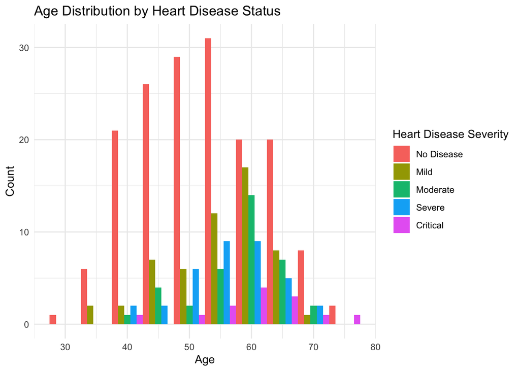

The histogram above illustrates the **Age distribution** of individuals categorized by heart disease severity. The **x-axis** represents age, while the **y-axis** represents the count of individuals within each age group.

- The **red bars** correspond to individuals with **no diagnosed heart disease**, forming the majority in younger age groups.
- The **other colors** (green, blue, and purple) represent **varying severity levels** of heart disease, with a noticeable increase in cases around the **50–60 age range**.
- A **higher frequency of heart disease cases** appears in older age groups, suggesting an **age-related risk factor** for heart disease.